# Optimal Treatment Analysis

## Outcome Variable

**Outcome Variable:** whz

## Predictor Variables

**Intervention Variable:** parity

**Adjustment Set:**

- arm
- W_mage
- meducyrs
- feducyrs
- hhwealth_quart
- W_mhtcm
- W_mwtkg
- W_mbmi
- vagbrth
- W_nrooms
- impsan
- delta_W_mage
- delta_meducyrs
- delta_feducyrs
- delta_hhwealth_quart
- delta_W_mhtcm
- delta_W_mwtkg
- delta_W_mbmi
- delta_vagbrth
- delta_W_nrooms
- delta_impsan

## Stratifying Variables

The analysis was stratified on these variable(s):

- agecat
- studyid
- country

## Data Summary

| agecat | studyid | country | parity | n_cell | n |
| --- | --- | --- | --- | --- | --- |
| Birth | COHORTS | GUATEMALA | 1 | 94 | 756 |
| Birth | COHORTS | GUATEMALA | 2 | 118 | 756 |
| Birth | COHORTS | GUATEMALA | 3+ | 544 | 756 |
| Birth | COHORTS | INDIA | 1 | 641 | 3855 |
| Birth | COHORTS | INDIA | 2 | 982 | 3855 |
| Birth | COHORTS | INDIA | 3+ | 2232 | 3855 |
| Birth | COHORTS | PHILIPPINES | 1 | 640 | 2899 |
| Birth | COHORTS | PHILIPPINES | 2 | 657 | 2899 |
| Birth | COHORTS | PHILIPPINES | 3+ | 1602 | 2899 |
| Birth | GMS-Nepal | NEPAL | 1 | 185 | 641 |
| Birth | GMS-Nepal | NEPAL | 2 | 169 | 641 |
| Birth | GMS-Nepal | NEPAL | 3+ | 287 | 641 |
| Birth | JiVitA-3 | BANGLADESH | 1 | 5520 | 18014 |
| Birth | JiVitA-3 | BANGLADESH | 2 | 6303 | 18014 |
| Birth | JiVitA-3 | BANGLADESH | 3+ | 6191 | 18014 |
| Birth | Keneba | GAMBIA | 1 | 146 | 1338 |
| Birth | Keneba | GAMBIA | 2 | 142 | 1338 |
| Birth | Keneba | GAMBIA | 3+ | 1050 | 1338 |
| Birth | PROVIDE | BANGLADESH | 1 | 202 | 532 |
| Birth | PROVIDE | BANGLADESH | 2 | 182 | 532 |
| Birth | PROVIDE | BANGLADESH | 3+ | 148 | 532 |
| Birth | SAS-CompFeed | INDIA | 1 | 304 | 1103 |
| Birth | SAS-CompFeed | INDIA | 2 | 258 | 1103 |
| Birth | SAS-CompFeed | INDIA | 3+ | 541 | 1103 |
| Birth | ZVITAMBO | ZIMBABWE | 1 | 5561 | 12916 |
| Birth | ZVITAMBO | ZIMBABWE | 2 | 3882 | 12916 |
| Birth | ZVITAMBO | ZIMBABWE | 3+ | 3473 | 12916 |
| 6 months | COHORTS | GUATEMALA | 1 | 132 | 963 |
| 6 months | COHORTS | GUATEMALA | 2 | 139 | 963 |
| 6 months | COHORTS | GUATEMALA | 3+ | 692 | 963 |

[output cut: 57 more lines]

The following strata were considered:

- agecat: 24 months, studyid: COHORTS, country: GUATEMALA
- agecat: 24 months, studyid: COHORTS, country: INDIA
- agecat: 24 months, studyid: COHORTS, country: PHILIPPINES
- agecat: 24 months, studyid: GMS-Nepal, country: NEPAL
- agecat: 24 months, studyid: JiVitA-3, country: BANGLADESH
- agecat: 24 months, studyid: Keneba, country: GAMBIA
- agecat: 24 months, studyid: PROVIDE, country: BANGLADESH
- agecat: 24 months, studyid: TanzaniaChild2, country: TANZANIA, UNITED REPUBLIC OF
- agecat: 24 months, studyid: ZVITAMBO, country: ZIMBABWE
- agecat: 6 months, studyid: COHORTS, country: GUATEMALA
- agecat: 6 months, studyid: COHORTS, country: INDIA
- agecat: 6 months, studyid: COHORTS, country: PHILIPPINES
- agecat: 6 months, studyid: GMS-Nepal, country: NEPAL
- agecat: 6 months, studyid: JiVitA-3, country: BANGLADESH
- agecat: 6 months, studyid: Keneba, country: GAMBIA
- agecat: 6 months, studyid: PROVIDE, country: BANGLADESH
- agecat: 6 months, studyid: SAS-CompFeed, country: INDIA
- agecat: 6 months, studyid: SAS-FoodSuppl, country: INDIA
- agecat: 6 months, studyid: TanzaniaChild2, country: TANZANIA, UNITED REPUBLIC OF
- agecat: 6 months, studyid: ZVITAMBO, country: ZIMBABWE
- agecat: Birth, studyid: COHORTS, country: GUATEMALA
- agecat: Birth, studyid: COHORTS, country: INDIA
- agecat: Birth, studyid: COHORTS, country: PHILIPPINES
- agecat: Birth, studyid: GMS-Nepal, country: NEPAL
- agecat: Birth, studyid: JiVitA-3, country: BANGLADESH
- agecat: Birth, studyid: Keneba, country: GAMBIA
- agecat: Birth, studyid: PROVIDE, country: BANGLADESH
- agecat: Birth, studyid: SAS-CompFeed, country: INDIA
- agecat: Birth, studyid: ZVITAMBO, country: ZIMBABWE

### Dropped Strata

Some strata were dropped due to rare outcomes:

- agecat: 24 months, studyid: TanzaniaChild2, country: TANZANIA, UNITED REPUBLIC OF

## Methods Detail

We’re interested in the causal parameters $E[Y_a]$ for all values of $a \in \mathcal{A}$. These parameters represent the mean outcome if, possibly contrary to fact, we intervened to set all units to have $A=a$. Under the randomization and positivity assumptions, these are identified by the statistical parameters $\psi_a=E_W[E_{Y|A,W}(Y|A=a,W)]$. In addition, we’re interested in the mean of $Y$, $E[Y]$ under no intervention (the observed mean). We will estimate these parameters by using SuperLearner to fit the relevant likelihood factors – $E_{Y|A,W}(Y|A=a,W)$ and $p(A=a|W)$, and then updating our likelihood fit using a joint TMLE.

For unadjusted analyses ($W=\{\}$), initial likelihoods were estimated using Lrnr_glm to estimate the simple $E(Y|A)$ and Lrnr_mean to estimate $p(A)$. For adjusted analyses, a small library containing Lrnr_glmnet, Lrnr_xgboost, and Lrnr_mean was used.

Having estimated these parameters, we will then use the delta method to estimate relative risks and attributable risks relative to a prespecified baseline level of $A$.

# Results Detail

## Results Plots

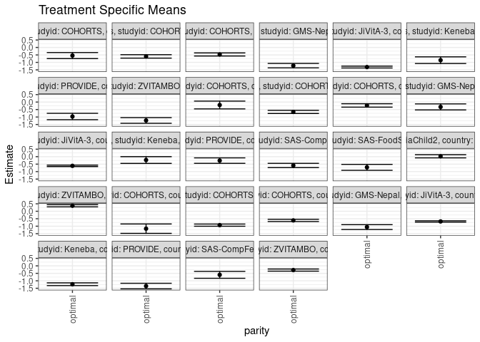

## Results Table

### Parameter: TSM

| agecat | studyid | country | intervention_level | baseline_level | estimate | ci_lower | ci_upper |
| --- | --- | --- | --- | --- | --- | --- | --- |
| Birth | COHORTS | GUATEMALA | optimal | observed | -1.1649154 | -1.4794820 | -0.8503487 |
| Birth | COHORTS | INDIA | optimal | observed | -0.9279561 | -1.0008102 | -0.8551021 |
| Birth | COHORTS | PHILIPPINES | optimal | observed | -0.6116055 | -0.6863782 | -0.5368328 |
| Birth | GMS-Nepal | NEPAL | optimal | observed | -1.0585465 | -1.2211386 | -0.8959543 |
| Birth | JiVitA-3 | BANGLADESH | optimal | observed | -0.6816904 | -0.7270967 | -0.6362841 |
| Birth | Keneba | GAMBIA | optimal | observed | -1.2300758 | -1.3217757 | -1.1383759 |
| Birth | PROVIDE | BANGLADESH | optimal | observed | -1.3518100 | -1.5382191 | -1.1654008 |
| Birth | SAS-CompFeed | INDIA | optimal | observed | -0.6007295 | -0.8312924 | -0.3701666 |
| Birth | ZVITAMBO | ZIMBABWE | optimal | observed | -0.2817576 | -0.3543853 | -0.2091298 |
| 6 months | COHORTS | GUATEMALA | optimal | observed | -0.1972251 | -0.4578409 | 0.0633906 |
| 6 months | COHORTS | INDIA | optimal | observed | -0.6600502 | -0.7642246 | -0.5558758 |
| 6 months | COHORTS | PHILIPPINES | optimal | observed | -0.2264287 | -0.3398438 | -0.1130136 |
| 6 months | GMS-Nepal | NEPAL | optimal | observed | -0.3258797 | -0.5283981 | -0.1233614 |
| 6 months | JiVitA-3 | BANGLADESH | optimal | observed | -0.6142716 | -0.6607322 | -0.5678110 |
| 6 months | Keneba | GAMBIA | optimal | observed | -0.2253934 | -0.4514726 | 0.0006858 |
| 6 months | PROVIDE | BANGLADESH | optimal | observed | -0.2634261 | -0.4459994 | -0.0808527 |
| 6 months | SAS-CompFeed | INDIA | optimal | observed | -0.5887602 | -0.7304473 | -0.4470732 |
| 6 months | SAS-FoodSuppl | INDIA | optimal | observed | -0.7148138 | -0.9142421 | -0.5153855 |
| 6 months | TanzaniaChild2 | TANZANIA, UNITED REPUBLIC OF | optimal | observed | 0.0245502 | -0.0812607 | 0.1303612 |
| 6 months | ZVITAMBO | ZIMBABWE | optimal | observed | 0.3682633 | 0.2961964 | 0.4403302 |
| 24 months | COHORTS | GUATEMALA | optimal | observed | -0.5426107 | -0.7439453 | -0.3412761 |
| 24 months | COHORTS | INDIA | optimal | observed | -0.5997208 | -0.7141128 | -0.4853287 |
| 24 months | COHORTS | PHILIPPINES | optimal | observed | -0.4690694 | -0.5723681 | -0.3657707 |
| 24 months | GMS-Nepal | NEPAL | optimal | observed | -1.2166758 | -1.3643815 | -1.0689701 |
| 24 months | JiVitA-3 | BANGLADESH | optimal | observed | -1.3112686 | -1.3736975 | -1.2488397 |
| 24 months | Keneba | GAMBIA | optimal | observed | -0.8523822 | -1.0758236 | -0.6289408 |
| 24 months | PROVIDE | BANGLADESH | optimal | observed | -0.9669110 | -1.1797289 | -0.7540932 |
| 24 months | ZVITAMBO | ZIMBABWE | optimal | observed | -1.2314224 | -1.4206260 | -1.0422188 |

### Parameter: E(Y)

| agecat | studyid | country | intervention_level | baseline_level | estimate | ci_lower | ci_upper |
| --- | --- | --- | --- | --- | --- | --- | --- |
| Birth | COHORTS | GUATEMALA | observed | observed | -1.0621429 | -1.1631387 | -0.9611471 |
| Birth | COHORTS | INDIA | observed | observed | -0.9498080 | -0.9874148 | -0.9122013 |
| Birth | COHORTS | PHILIPPINES | observed | observed | -0.7427251 | -0.7890855 | -0.6963647 |
| Birth | GMS-Nepal | NEPAL | observed | observed | -1.1164431 | -1.2040134 | -1.0288728 |
| Birth | JiVitA-3 | BANGLADESH | observed | observed | -0.7778272 | -0.7968313 | -0.7588232 |
| Birth | Keneba | GAMBIA | observed | observed | -1.2037220 | -1.2694226 | -1.1380213 |
| Birth | PROVIDE | BANGLADESH | observed | observed | -1.2984586 | -1.3752758 | -1.2216415 |
| Birth | SAS-CompFeed | INDIA | observed | observed | -0.6700453 | -0.8474950 | -0.4925957 |
| Birth | ZVITAMBO | ZIMBABWE | observed | observed | -0.5156349 | -0.5414936 | -0.4897762 |
| 6 months | COHORTS | GUATEMALA | observed | observed | 0.1940810 | 0.1226351 | 0.2655269 |
| 6 months | COHORTS | INDIA | observed | observed | -0.7068611 | -0.7417800 | -0.6719423 |
| 6 months | COHORTS | PHILIPPINES | observed | observed | -0.2938433 | -0.3352064 | -0.2524802 |
| 6 months | GMS-Nepal | NEPAL | observed | observed | -0.6038416 | -0.6899448 | -0.5177384 |
| 6 months | JiVitA-3 | BANGLADESH | observed | observed | -0.5935161 | -0.6130518 | -0.5739805 |
| 6 months | Keneba | GAMBIA | observed | observed | -0.1873900 | -0.2456638 | -0.1291162 |
| 6 months | PROVIDE | BANGLADESH | observed | observed | -0.1990907 | -0.2817968 | -0.1163845 |
| 6 months | SAS-CompFeed | INDIA | observed | observed | -0.6657084 | -0.8024377 | -0.5289791 |
| 6 months | SAS-FoodSuppl | INDIA | observed | observed | -1.0121579 | -1.1280429 | -0.8962729 |
| 6 months | TanzaniaChild2 | TANZANIA, UNITED REPUBLIC OF | observed | observed | 0.0797179 | 0.0266621 | 0.1327737 |
| 6 months | ZVITAMBO | ZIMBABWE | observed | observed | 0.3106432 | 0.2849661 | 0.3363203 |
| 24 months | COHORTS | GUATEMALA | observed | observed | -0.2813755 | -0.3354674 | -0.2272835 |
| 24 months | COHORTS | INDIA | observed | observed | -0.6564729 | -0.6914450 | -0.6215007 |
| 24 months | COHORTS | PHILIPPINES | observed | observed | -0.6099592 | -0.6467541 | -0.5731643 |
| 24 months | GMS-Nepal | NEPAL | observed | observed | -1.1363107 | -1.2252817 | -1.0473398 |
| 24 months | JiVitA-3 | BANGLADESH | observed | observed | -1.2978031 | -1.3210763 | -1.2745298 |
| 24 months | Keneba | GAMBIA | observed | observed | -0.7834078 | -0.8357743 | -0.7310414 |
| 24 months | PROVIDE | BANGLADESH | observed | observed | -0.8928670 | -0.9755153 | -0.8102187 |
| 24 months | ZVITAMBO | ZIMBABWE | observed | observed | -1.1817824 | -1.2809226 | -1.0826422 |

### Parameter: PAR

| agecat | studyid | country | intervention_level | baseline_level | estimate | ci_lower | ci_upper |
| --- | --- | --- | --- | --- | --- | --- | --- |
| Birth | COHORTS | GUATEMALA | optimal | observed | 0.1027725 | -0.1888298 | 0.3943749 |
| Birth | COHORTS | INDIA | optimal | observed | -0.0218519 | -0.0844312 | 0.0407274 |
| Birth | COHORTS | PHILIPPINES | optimal | observed | -0.1311196 | -0.1923305 | -0.0699087 |
| Birth | GMS-Nepal | NEPAL | optimal | observed | -0.0578966 | -0.2045362 | 0.0887430 |
| Birth | JiVitA-3 | BANGLADESH | optimal | observed | -0.0961369 | -0.1398201 | -0.0524536 |
| Birth | Keneba | GAMBIA | optimal | observed | 0.0263538 | -0.0380317 | 0.0907393 |
| Birth | PROVIDE | BANGLADESH | optimal | observed | 0.0533513 | -0.1122880 | 0.2189906 |
| Birth | SAS-CompFeed | INDIA | optimal | observed | -0.0693158 | -0.1643119 | 0.0256802 |
| Birth | ZVITAMBO | ZIMBABWE | optimal | observed | -0.2338773 | -0.3034785 | -0.1642762 |
| 6 months | COHORTS | GUATEMALA | optimal | observed | 0.3913061 | 0.1394968 | 0.6431155 |
| 6 months | COHORTS | INDIA | optimal | observed | -0.0468109 | -0.1452714 | 0.0516495 |
| 6 months | COHORTS | PHILIPPINES | optimal | observed | -0.0674146 | -0.1764218 | 0.0415926 |
| 6 months | GMS-Nepal | NEPAL | optimal | observed | -0.2779619 | -0.4731308 | -0.0827930 |
| 6 months | JiVitA-3 | BANGLADESH | optimal | observed | 0.0207554 | -0.0219779 | 0.0634888 |
| 6 months | Keneba | GAMBIA | optimal | observed | 0.0380034 | -0.1829698 | 0.2589766 |
| 6 months | PROVIDE | BANGLADESH | optimal | observed | 0.0643354 | -0.0990357 | 0.2277065 |
| 6 months | SAS-CompFeed | INDIA | optimal | observed | -0.0769481 | -0.2067814 | 0.0528851 |
| 6 months | SAS-FoodSuppl | INDIA | optimal | observed | -0.2973441 | -0.4938890 | -0.1007991 |
| 6 months | TanzaniaChild2 | TANZANIA, UNITED REPUBLIC OF | optimal | observed | 0.0551677 | -0.0386198 | 0.1489551 |
| 6 months | ZVITAMBO | ZIMBABWE | optimal | observed | -0.0576201 | -0.1259860 | 0.0107458 |
| 24 months | COHORTS | GUATEMALA | optimal | observed | 0.2612352 | 0.0658173 | 0.4566532 |
| 24 months | COHORTS | INDIA | optimal | observed | -0.0567521 | -0.1662548 | 0.0527506 |
| 24 months | COHORTS | PHILIPPINES | optimal | observed | -0.1408898 | -0.2381971 | -0.0435825 |
| 24 months | GMS-Nepal | NEPAL | optimal | observed | 0.0803650 | -0.0561078 | 0.2168379 |
| 24 months | JiVitA-3 | BANGLADESH | optimal | observed | 0.0134655 | -0.0454149 | 0.0723459 |
| 24 months | Keneba | GAMBIA | optimal | observed | 0.0689744 | -0.1485244 | 0.2864732 |
| 24 months | PROVIDE | BANGLADESH | optimal | observed | 0.0740440 | -0.1157587 | 0.2638467 |
| 24 months | ZVITAMBO | ZIMBABWE | optimal | observed | 0.0496400 | -0.1120682 | 0.2113481 |